# Practical Machine Learning : Prediction of excercise manner

# Background

Using devices such as Jawbone Up, Nike FuelBand, and Fitbit it is now possible to collect a large amount of data about personal activity relatively inexpensively. These type of devices are part of the quantified self movement - a group of enthusiasts who take measurements about themselves regularly to improve their health, to find patterns in their behavior, or because they are tech geeks. One thing that people regularly do is quantify how much of a particular activity they do, but they rarely quantify how well they do it. In this project, your goal will be to use data from accelerometers on the belt, forearm, arm, and dumbell of 6 participants. They were asked to perform barbell lifts correctly and incorrectly in 5 different ways. More information is available from the website here: http://groupware.les.inf.puc-rio.br/har (see the section on the Weight Lifting Exercise Dataset).

# Data

The training data for this project are available here:

https://d396qusza40orc.cloudfront.net/predmachlearn/pml-training.csv

The test data are available here:

https://d396qusza40orc.cloudfront.net/predmachlearn/pml-testing.csv

The data for this project come from this source: http://groupware.les.inf.puc-rio.br/har. If you use the document you create for this class for any purpose please cite them as they have been very generous in allowing their data to be used for this kind of assignment.

# Goal

The goal of this project is to predict the manner in which they did the exercise. This is the “classe” variable in the training set. Following report describes how model is built, how cross validation is used, what is the expected out of sample error is, and why the choices made. The prediction model is used to predict 20 different test cases

# Load the required paackages

```r
library(caret)
library(randomForest)
```

# Getting and Cleaning Data

1. Download data sets using provided URLs if not exist.

```r
# Download training data set if not exists
trainDS <- "pml-training.csv"
if (!file.exists(trainDS)) {
  download.file("https://d396qusza40orc.cloudfront.net/predmachlearn/pml-training.csv",
                destfile=trainDS, method="curl")
}

# Download test data set if not exists
testDS  <- "pml-testing.csv"
if (!file.exists(testDS)) {
  download.file("https://d396qusza40orc.cloudfront.net/predmachlearn/pml-testing.csv",
                destfile=testDS, method="curl")
}
```

2. Read data sets into data frames.

```r
# Read training data set into a data frame
trainDF <- read.csv(trainDS)

# Display the dimensions of training data frame
dim(trainDF)
```

```
## [1] 19622   160
```

```r
# Read test data set into a data frame
testDF <- read.csv(testDS)

# Display the dimensions of test data frame
dim(testDF)
```

```
## [1]  20 160
```

3. Clean data frames to remove the columns containing missing values and columns that cannot be used for measurements.

```r
# Remove the columns that contain missing values
trainDF <- trainDF[, colSums(is.na(trainDF)) == 0]
testDF <- testDF[, colSums(is.na(testDF)) == 0]

# Remove non numeric columns which cannot be used for measurements except classe
trainDFclasse <- trainDF$classe
trainDF <- trainDF[, sapply(trainDF, is.numeric)]
trainDF$classe <- trainDFclasse
testDF <- testDF[, sapply(testDF, is.numeric)]

# Remove first 4 columns which are not used for measurements
trainDF <- trainDF[, 5:length(names(trainDF))]
testing <- testDF[, 5:length(names(testDF))]

# Display the dimensions of training data frame
dim(trainDF)
```

```
## [1] 19622    53
```

```r
# Display the dimensions of testing data frame
dim(testing)
```

```
## [1] 20 53
```

4. Partition the train data frame into a pure train data frame(70%) and a validation data frame(30%) used for cross validation.

```r
# Set seed for reproducibility
set.seed(13234)

# Partition train data frame into 70 : 30 data frames
inTrain = createDataPartition(trainDF$classe, p = 0.7, list=FALSE)
training = trainDF[inTrain,]
validation = trainDF[-inTrain,]

# Display the dimensions of training data frame
dim(training)
```

```
## [1] 13737    53
```

```r
# Display the dimensions of validation data frame
dim(validation)
```

```
## [1] 5885   53
```

```r
# Display the dimensions of testing data frame
dim(testing)
```

```
## [1] 20 53
```

# Building Model

We will build model for training data using method random forest and using train control method 5-fold cross validation. We have used method random forest as it results into high accuracy rate.

```r
# Train the model
modFit <- train(classe ~.,
                method="rf",
                data=training,
                trControl= trainControl(method='cv', 5),
                ntree=250)

# Display the model
modFit
```

```
## Random Forest
##
## 13737 samples
##    52 predictor
##     5 classes: 'A', 'B', 'C', 'D', 'E'
##
## No pre-processing
## Resampling: Cross-Validated (5 fold)
## Summary of sample sizes: 10991, 10988, 10988, 10991, 10990
## Resampling results across tuning parameters:
##
##   mtry  Accuracy   Kappa      Accuracy SD  Kappa SD
##    2    0.9900268  0.9873829  0.001599260  0.002023224
##   27    0.9914827  0.9892253  0.001328395  0.001680876
##   52    0.9864601  0.9828706  0.002142550  0.002709351
##
## Accuracy was used to select the optimal model using  the largest value.
## The final value used for the model was mtry = 27.
```

```r
## Display the variable importance
varImp(modFit)
```

```
## rf variable importance
##
##   only 20 most important variables shown (out of 52)
##
##                      Overall
## roll_belt             100.00
## pitch_forearm          61.02
## yaw_belt               56.38
## magnet_dumbbell_z      44.76
## pitch_belt             43.06
## magnet_dumbbell_y      41.95
## roll_forearm           37.98
## accel_dumbbell_y       22.44
## roll_dumbbell          18.59
## magnet_dumbbell_x      18.26
## accel_forearm_x        16.94
## magnet_belt_z          14.56
## accel_dumbbell_z       14.20
## accel_belt_z           13.88
## magnet_forearm_z       13.38
## magnet_belt_y          13.17
## total_accel_dumbbell   12.94
## gyros_belt_z           11.31
## yaw_arm                10.62
## magnet_belt_x          10.31
```

```r
# Display the final model
modFit$finalModel
```

```
##
## Call:
##  randomForest(x = x, y = y, ntree = 250, mtry = param$mtry)
##                Type of random forest: classification
##                      Number of trees: 250
## No. of variables tried at each split: 27
##
##         OOB estimate of  error rate: 0.71%
## Confusion matrix:
##      A    B    C    D    E class.error
## A 3902    4    0    0    0 0.001024066
## B   24 2625    8    1    0 0.012415350
## C    0   16 2371    9    0 0.010434057
## D    0    0   21 2229    2 0.010213144
## E    0    1    5    7 2512 0.005148515
```

# Evaluating Model for validation data set

We will evaluate the model on validation data set.

```r
# Evaluate model on validation data set
predictValidation <- predict(modFit, validation)

# Display confusionMatrix
cm <- confusionMatrix(validation$classe, predictValidation)
cm
```

```
## Confusion Matrix and Statistics
##
##           Reference
## Prediction    A    B    C    D    E
##          A 1673    0    0    0    1
##          B    3 1131    5    0    0
##          C    0    6 1012    8    0
##          D    0    0    9  953    2
##          E    0    1    4    0 1077
##
## Overall Statistics
##
##                Accuracy : 0.9934
##                  95% CI : (0.991, 0.9953)
##     No Information Rate : 0.2848
##     P-Value [Acc > NIR] : < 2.2e-16
##
##                   Kappa : 0.9916
##  Mcnemar's Test P-Value : NA
##
## Statistics by Class:
##
##                      Class: A Class: B Class: C Class: D Class: E
## Sensitivity            0.9982   0.9938   0.9825   0.9917   0.9972
## Specificity            0.9998   0.9983   0.9971   0.9978   0.9990
## Pos Pred Value         0.9994   0.9930   0.9864   0.9886   0.9954
## Neg Pred Value         0.9993   0.9985   0.9963   0.9984   0.9994
## Prevalence             0.2848   0.1934   0.1750   0.1633   0.1835
## Detection Rate         0.2843   0.1922   0.1720   0.1619   0.1830
## Detection Prevalence   0.2845   0.1935   0.1743   0.1638   0.1839
## Balanced Accuracy      0.9990   0.9961   0.9898   0.9947   0.9981
```

```r
# Estimate the accuracy percentage
accuracy <- as.numeric(cm$overall[1]) * 100
accuracy
```

```
## [1] 99.3373
```

```r
# Estimate out of sample error percentage
out_of_sample_error <- (1 - as.numeric(cm$overall[1]))* 100
out_of_sample_error
```

```
## [1] 0.6627018
```

So, the estimated accuracy of the model is 99.3372982% and the estimated out of sample error is 0.6627018%.

# Evaluating Model for test data set

We will evaluate the model on test data set.

```r
## Evaluate model on testing data set
predict(modFit, testing)
```

```
##  [1] B A B A A E D B A A B C B A E E A B B B
## Levels: A B C D E
```

# Figures

We will plot various models.

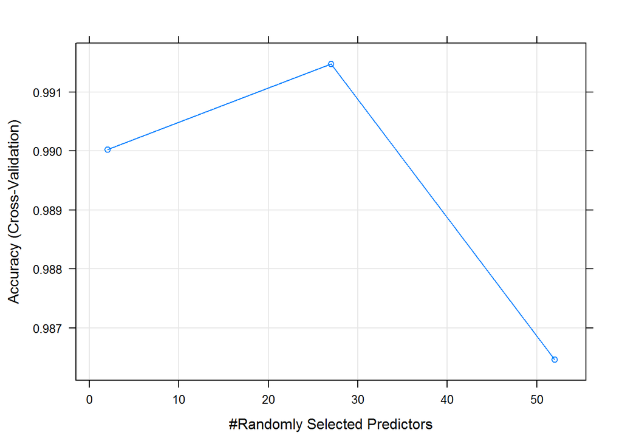

```r
# plot model
plot(modFit)
```

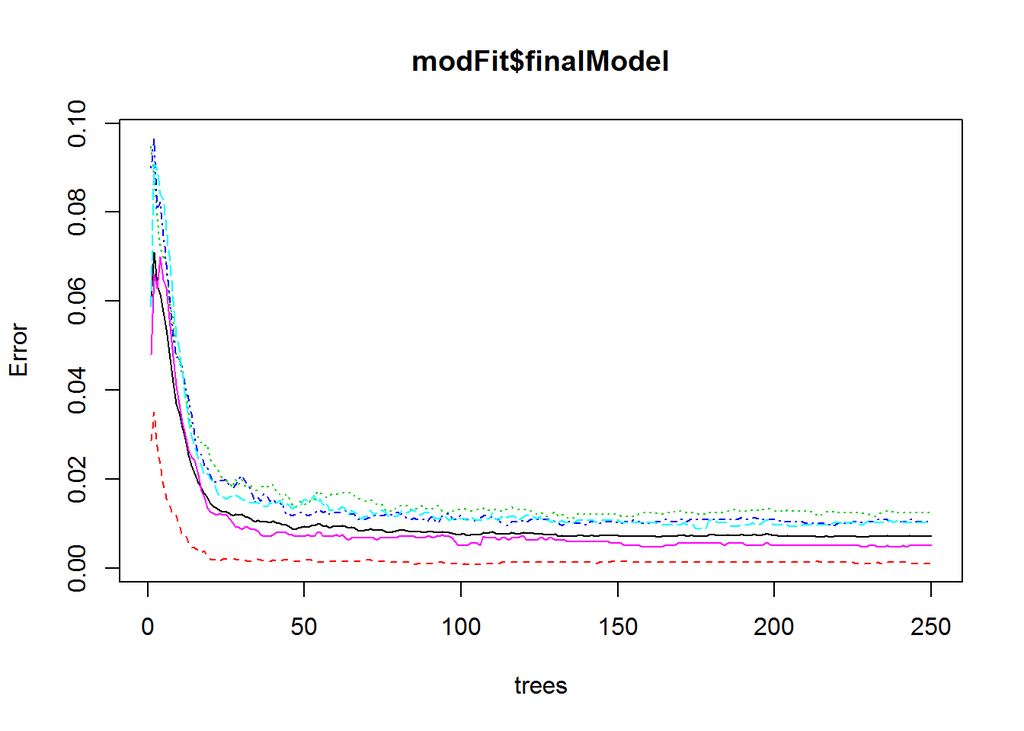

```r
# plot the final model
plot(modFit$finalModel)
```

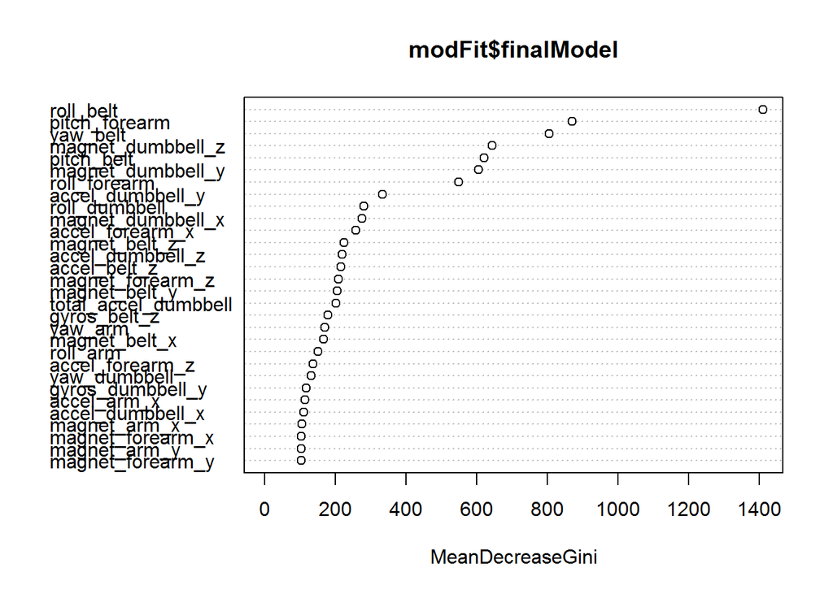

```r
# plot the variable importance
varImpPlot(modFit$finalModel)
```